# Teste T (de Student) para duas amostras independentes

## ANOVA de dois fatores ou Anova fatorial

Este teste considera delineamentos amostrais com dois fatores (ou tratamento) que podem ser compostos por dois ou mais grupos (ou níveis). Esta análise tem uma vantagem, pois permite avaliar o efeito da interação entre os fatores na variável resposta. Quando a interação está presente, o impacto de um fator depende do nível (ou grupo) do outro fator.

#### Exemplo prático 1 - Anova de dois fatores

##### Explicação dos dados

Neste exemplo, avaliaremos se o tempo que o corpo leva para elimiar uma droga utilizada em exames de ressonância magnética está relacionado com o sistema XY de determinação do sexo e/ou com a idade dos pacientes. Para isso, foi realizado um experimento com 40 pacientes distribuídos da seguinte maneira: i) 10 indivíduos XX - jovens, ii) 10 indivíduos XX - idosas, iii) 10 indivíduos XY - jovens, e iv) 10 indivíduos XY - idosos.

**Pergunta:**

> O tempo de eliminação da droga é dependente do sistema XY de determinação do sexo e idade dos pacientes?

**Predições**

> O tempo de eliminação da droga vai ser mais rápido nas pacientes XX e jovens.

**Variáveis**

- Variáveis preditoras
  - Dataframe com os pacientes (unidade amostral) nas linhas e os tratamentos nas colunas.

**Checklist**

- Verificar se o seu dataframe está com as unidades amostrais nas linhas e as variáveies preditoras nas colunas.

### Análise

Cálculo da Anova de dois fator

```r
## IMPORTANDO DADOS
#********************
dados_dois_fatores <- read.csv("anova_dois_fatores.csv", header = T, sep = ";")
head(dados_dois_fatores)
```

```
##    Tempo Pessoas Idade
## 1 18.952      XX Jovem
## 2 16.513      XX Jovem
## 3 17.981      XX Jovem
## 4 21.371      XX Jovem
## 5 14.470      XX Jovem
## 6 19.130      XX Jovem
```

```r
# Análise anova de dois fatores
#********************************
# A interação entre os fatores é representada por *
Modelo1 <- aov(Tempo ~ Pessoas * Idade, data = dados_dois_fatores)

# Olhando os resultados
anova(Modelo1)
```

```
## Analysis of Variance Table
##
## Response: Tempo
##               Df  Sum Sq Mean Sq  F value    Pr(>F)
## Pessoas        1  716.72  716.72 178.8538  1.56e-15 ***
## Idade          1 1663.73 1663.73 415.1724 < 2.2e-16 ***
## Pessoas:Idade  1    4.77    4.77   1.1903    0.2825
## Residuals     36  144.26    4.01
## ---
## Signif. codes:  0 '***' 0.001 '**' 0.01 '*' 0.05 '.' 0.1 ' ' 1
```

```r
# Percebam que a interação não apresenta um efeito significativo (P > 0.05). Assim, iremos retirar a interação e verificar, usando LIKELIHOOD RATIO TEST (LRT), se o modelo mais simples é melhor
Modelo2 <- aov(Tempo ~ Pessoas + Idade, data = dados_dois_fatores)

# A hipótese nula é que o modelo mais simples é melhor
# Valores de p < 0.05 rejeita a hipótese nula e o modelo mais complexo é o melhor
# Valores de p > 0.05 não rejeita a hipótese nula e o modelo mais simples é o melhor
library(lmtest)
lrtest(Modelo1, Modelo2)
```

```
## Likelihood ratio test
##
## Model 1: Tempo ~ Pessoas * Idade
## Model 2: Tempo ~ Pessoas + Idade
##   #Df  LogLik Df  Chisq Pr(>Chisq)
## 1   5 -82.413
## 2   4 -83.063 -1 1.3012      0.254
```

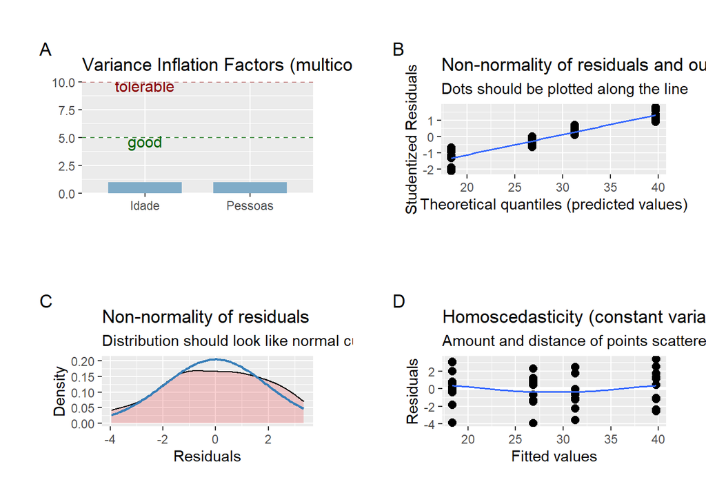

```r
# VERIFICANDO A NORMALIDADE E HOMOGENEIDADE DAS VARIÂNCIAS
#***********************************************************************
# Esta função mostra os resultados para multicolinearidade (a), dois gráficos avaliando a normalidade dos resíduos (b e  c), e um gráfico para a homogeneidade dos resíduos (d).
library(sjPlot)
plot_grid(plot_model(Modelo2, type = "diag"))
```

```r
# VERIFICANDO OS RESULTADOS DA ANOVA
#****************************************
anova(Modelo2)
```

```
## Analysis of Variance Table
##
## Response: Tempo
##           Df  Sum Sq Mean Sq F value    Pr(>F)
## Pessoas    1  716.72  716.72  177.94 1.041e-15 ***
## Idade      1 1663.73 1663.73  413.05 < 2.2e-16 ***
## Residuals 37  149.03    4.03
## ---
## Signif. codes:  0 '***' 0.001 '**' 0.01 '*' 0.05 '.' 0.1 ' ' 1
```

Percebam que o resultado da Anova (Pr(>F) < 0.001) indica que devemos rejeitar a hipótese nula que não há diferença entre as médias dos sistema XY e idade dos pacientes. Neste caso, não precisamos realizar testes de comparações múltiplas *post-hoc* porque os fatores apresentam apenas dois níveis. Contudo, se no seu delineamento experimental um dos fatores apresentar três ou mais níveis, você deverá utilizar os testes de comparações *post-hoc* para determinar as diferenças entre os grupos. **Observação** Os testes *post-hoc* só devem ser utilizados quando rejeitamos a hipótese nula (P < 0.05) no teste da Anova.

```r
# Diferenças entre os tratamentos
#***********************************
# Teste de Tuckey's honest significant difference
TukeyHSD(Modelo2)
```

```
##   Tukey multiple comparisons of means
##     95% family-wise confidence level
##
## Fit: aov(formula = Tempo ~ Pessoas + Idade, data = dados_dois_fatores)
##
## $Pessoas
##          diff      lwr      upr p adj
## XY-XX 8.46595 7.180008 9.751892     0
##
## $Idade
##                  diff       lwr       upr p adj
## Jovem-Idoso -12.89855 -14.18449 -11.61261     0
```

Visualizar os resultados em gráfico

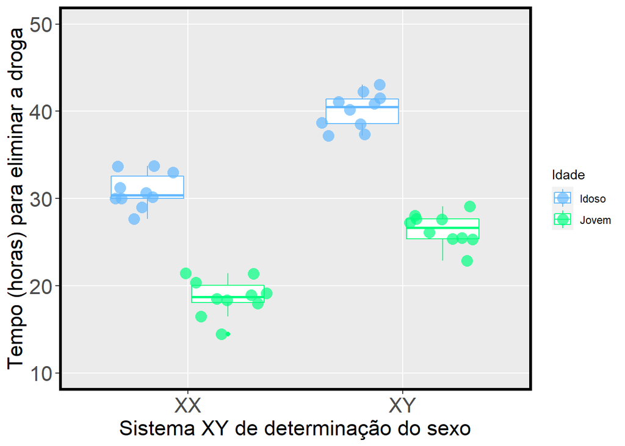

```r
# Gráfico
library(ggplot2)
ggplot(data = dados_dois_fatores, aes(y= Tempo, x= Pessoas, color = Idade)) +
  geom_boxplot() +
  labs(x = "Sistema XY de determinação do sexo", y = "Tempo (horas) para eliminar a droga",
       size = 20) +
  geom_jitter(shape = 16, position=position_jitterdodge(), cex = 4, alpha = 0.7) +
  scale_color_manual(values = c("steelblue1", "springgreen1")) +
  scale_y_continuous(limits = c(10, 50), breaks = c(10, 20, 30, 40, 50)) +
  theme(axis.title.y = element_text(size = 17), axis.title.x = element_text(size = 17)) +
  theme(axis.text.y = element_text(size = 17), axis.text.x = element_text(size = 17)) +
  theme(panel.grid.minor = element_blank(),
        panel.border = element_rect(colour = "black", fill=NA, size = 2))
```

**Interpretação dos resultados**

Neste exemplo, O sitesma XY de determinação do sexo e a idade dos pacientes tem um efeito no tempo de eliminação da droga do organismo. Os pacientes XX e jovens apresentam eliminação mais rápida da droga do que pacientes XY e idosos.

#### Exemplo prático 2 - Anova de dois fatores com efeito da interação

##### Explicação dos dados

Neste exemplo usaremos os mesmos dados do exemplo anterior. Neste caso, alteremos os dados para que a interação seja significativa.

```r
## IMPORTANDO DADOS
#********************
dados_dois_fatores_interacao <- read.csv("anova_dois_fatores_interacao1.csv",
                                         header = T, sep = ";")
head(dados_dois_fatores_interacao)
```

```
##    Tempo Pessoas Idade
## 1 31.092      XX Jovem
## 2 27.331      XX Jovem
## 3 24.874      XX Jovem
## 4 27.369      XX Jovem
## 5 28.125      XX Jovem
## 6 29.607      XX Jovem
```

```r
# Análise anova de dois fatores
#********************************
# A interação entre os fatores é representada por *
Modelo_interacao1 <- aov(Tempo ~ Pessoas * Idade, data =dados_dois_fatores_interacao)

# Olhando os resultados
anova(Modelo_interacao1)
```

```
## Analysis of Variance Table
##
## Response: Tempo
##               Df Sum Sq Mean Sq F value    Pr(>F)
## Pessoas        1 128.04  128.04  34.841 9.377e-07 ***
## Idade          1 641.75  641.75 174.623 2.236e-15 ***
## Pessoas:Idade  1 311.17  311.17  84.672 5.463e-11 ***
## Residuals     36 132.30    3.68
## ---
## Signif. codes:  0 '***' 0.001 '**' 0.01 '*' 0.05 '.' 0.1 ' ' 1
```

Percebam que a interação é significativa (P < 0.05). Agora nossa interpretação precisa ser baseada na interação entre os fatores. Vamos visualizar os resultados em gráfico.

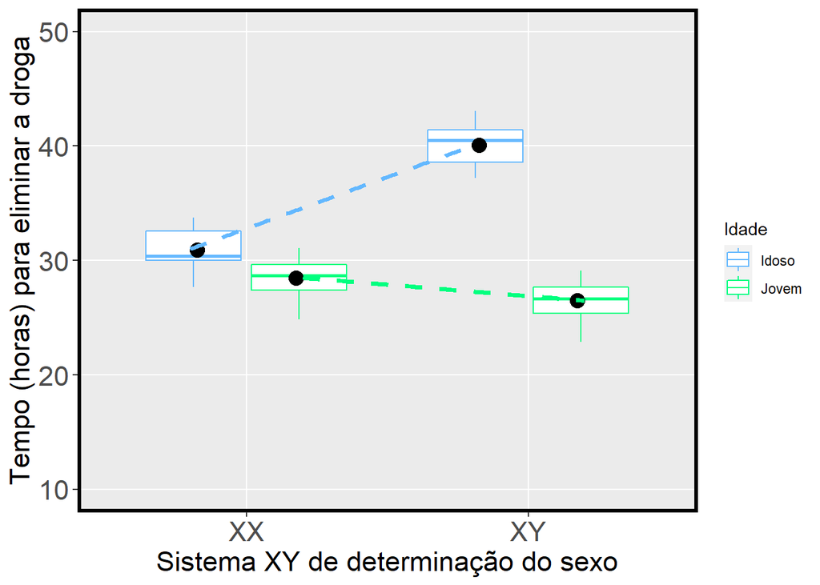

```r
# Gráfico
library(ggplot2)
library(ggforce)
ggplot(data = dados_dois_fatores_interacao, aes(y= Tempo, x= Pessoas, color = Idade)) +
  geom_boxplot() +
  stat_summary(fun = mean, geom="point", aes(group=Idade, x = Pessoas), color = "black",
               position = position_dodge(0.7), size  = 4) +
  geom_link(aes(x = 0.8, y = 31, xend = 1.8, yend = 40), color = "steelblue1",
            lwd  = 1.3, linetype = 2) +
  geom_link(aes(x = 1.2, y = 28.5, xend = 2.2, yend = 26.5), color = "springgreen1",
            lwd  = 1.3, linetype = 2) +
  labs(x = "Sistema XY de determinação do sexo", y = "Tempo (horas) para eliminar a droga",
       size = 20) +
  scale_color_manual(values = c("steelblue1", "springgreen1", "steelblue1",
                                "springgreen1")) +
  scale_y_continuous(limits = c(10, 50), breaks = c(10, 20, 30, 40, 50)) +
  theme(axis.title.y = element_text(size = 17), axis.title.x = element_text(size = 17)) +
  theme(axis.text.y = element_text(size = 17), axis.text.x = element_text(size = 17)) +
  theme(panel.grid.minor = element_blank(),
        panel.border = element_rect(colour = "black", fill=NA, size = 2))
```

**Interpretação dos resultados**

Percebam que para saber a resposta do fator idade (jovem ou idoso) na eliminação da droga, você precisa saber com qual pessoa (XX ou XY) ele está associado. Isso porque a resposta de um fator depende do outro fator. Jovens eliminam o droga do corpo mais rápido nas pessoa XY enquanto os idosos eliminam a droga mais rápido nas pessoas XX.

#### Exemplo prático 3 - Anova de dois fatores com efeito da interação

##### Explicação dos dados

Neste exemplo usaremos os mesmos dados do exemplo anterior. Neste caso, alteremos os dados para que a interação seja significativa.

```r
## IMPORTANDO DADOS
#********************
dados_dois_fatores_interacao2 <- read.csv("anova_dois_fatores_interacao2.csv",
                                          header = T, sep = ";")
head(dados_dois_fatores_interacao2)
```

```
##    Tempo Pessoas Idade
## 1 18.952      XX Jovem
## 2 16.513      XX Jovem
## 3 17.981      XX Jovem
## 4 21.371      XX Jovem
## 5 14.470      XX Jovem
## 6 19.130      XX Jovem
```

```r
# Análise anova de dois fatores
#********************************
# A interação entre os fatores é representada por *
Modelo_interacao2 <- aov(Tempo ~ Pessoas * Idade, data = dados_dois_fatores_interacao2)

# Olhando os resultados
anova(Modelo_interacao2)
```

```
## Analysis of Variance Table
##
## Response: Tempo
##               Df  Sum Sq Mean Sq  F value    Pr(>F)
## Pessoas        1  716.72  716.72 178.8538  1.56e-15 ***
## Idade          1    4.77    4.77   1.1903    0.2825
## Pessoas:Idade  1 1663.73 1663.73 415.1724 < 2.2e-16 ***
## Residuals     36  144.26    4.01
## ---
## Signif. codes:  0 '***' 0.001 '**' 0.01 '*' 0.05 '.' 0.1 ' ' 1
```

Percebam que a interação é significativa (P < 0.05), mas a idade não é significativa. Nossa interpretação precisa ser baseada na interação entre os fatores. Vamos visualizar os resultados em gráfico.

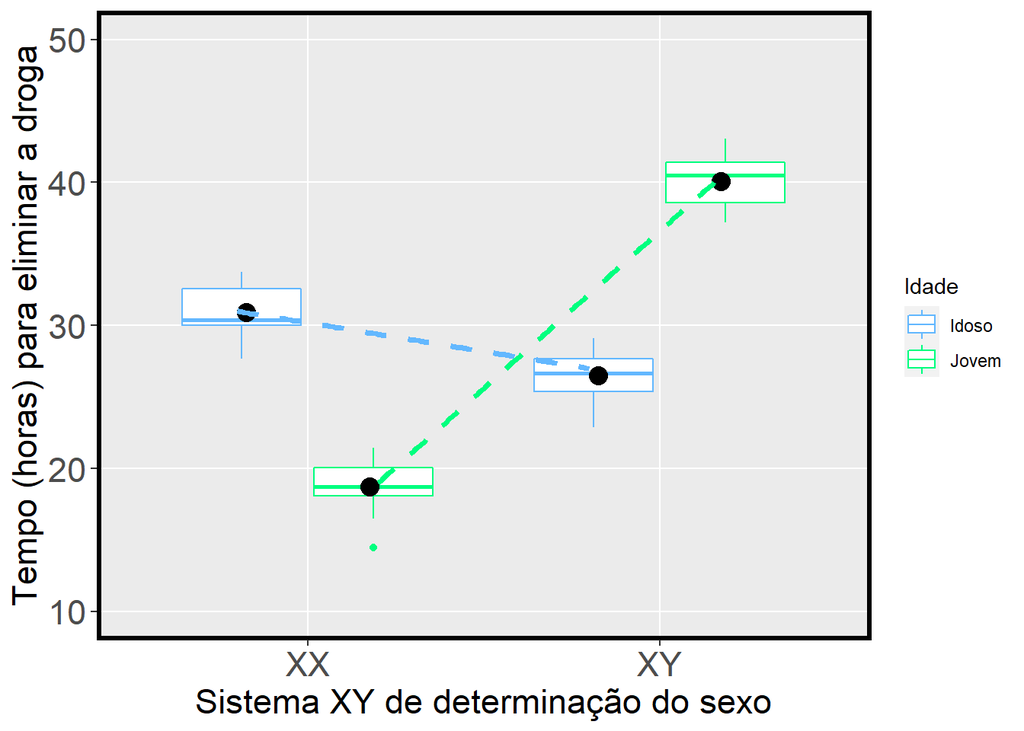

```r
# Gráfico
library(ggplot2)
library(ggforce)
ggplot(data = dados_dois_fatores_interacao2, aes(y= Tempo, x= Pessoas, color = Idade)) +
  geom_boxplot() +
  stat_summary(fun = mean, geom="point", aes(group=Idade, x = Pessoas), color = "black",
               position = position_dodge(0.7), size  = 4) +
  geom_link(aes(x = 0.8, y = 31, xend = 1.8, yend = 27), color = "steelblue1",
            lwd  = 1.3, linetype = 2) +
  geom_link(aes(x = 1.2, y = 19, xend = 2.2, yend = 41), color = "springgreen1",
            lwd  = 1.3, linetype = 2) +
  labs(x = "Sistema XY de determinação do sexo", y = "Tempo (horas) para eliminar a droga",
       size = 20) +
  scale_color_manual(values = c("steelblue1", "springgreen1", "steelblue1", "springgreen1")) +
  scale_y_continuous(limits = c(10, 50), breaks = c(10, 20, 30, 40, 50)) +
  theme(axis.title.y = element_text(size = 17), axis.title.x = element_text(size = 17)) +
  theme(axis.text.y = element_text(size = 17), axis.text.x = element_text(size = 17)) +
  theme(panel.grid.minor = element_blank(),
        panel.border = element_rect(colour = "black", fill=NA, size = 2))
```

**Interpretação dos resultados**

Percebam que as linhas se cruzam. Esse é exemplo clássico de interação. Novamente, para saber a resposta do fator idade (jovem ou idoso), você precisa saber com qual pessoa (XX ou XY) ele está associado. Jovens são mais rápidos para eliminar a droga em pessoas XX enquanto os idosos são mais rápidos para eliminar a droga nas pessoas XY.

## ANOVA em blocos aleatorizados

No delineamento experimental com blocos aleatorizados, cada fator é agrupado em blocos, com réplicas de cada nível do fator representado em cada bloco (Gotelli & Elisson 2013). O bloco é uma área ou período de tempo dentro do qual as condições ambientais são relativamente homogêneas. O objetivo do uso dos blocos é controlar fontes de variações indesejadas na variável dependente que não são de interesse do pesquisador. Desta maneira, podemos retirar dos resíduos, os efeitos das variações indesejadas que não do nosso interesse, e testar com maior poder estatístico os efeitos dos tratamentos de interesse. Importante, os blocos devem ser arranjados de forma que as condições ambientais sejam mais similares dentro dos blocos do que entre os blocos.

#### Exemplo prático 1 - Anova em blocos aleatorizados

##### Explicação dos dados

**Pergunta:**

> A distância da poça artifical ao fragmento florestal influência a riqueza de espécies anuros?

**Predições**

> Poças na borda do fragmento florestal apresentarão maior riqueza de espécies do que poças distantes da borda.

**Variáveis**

- Variáveis preditoras
  - Dataframe com as poças (unidade amostral) nas linhas e o tratamento e bloco nas colunas.

**Checklist**

- Verificar se o seu dataframe está com as unidades amostrais nas linhas e variáveis preditoras nas colunas.

### Análise

Cálculo da Anova em blocos aleatorizados

```r
## IMPORTANDO DADOS
#********************
dados_bloco <- read.csv("anova_bloco.csv", header = T, sep = ";")
str(dados_bloco) # verificar se o dataframe foi lido corretamente
```

```
## 'data.frame':    30 obs. of  3 variables:
##  $ Riqueza: int  90 95 107 92 89 92 81 92 93 80 ...
##  $ Blocos : chr  "A" "A" "A" "A" ...
##  $ Pocas  : chr  "Int-50m" "Int-100m" "Borda" "Mat-50m" ...
```

```r
# ANALISE ANOVA em blocos aleatorizados
#****************************************
# Há duas maneiras para incluir os efeitos dos blocos
model_bloco1 <- aov(Riqueza ~ Pocas + Blocos, data = dados_bloco)

model_bloco2 <- aov(Riqueza ~ Pocas + Error(Blocos), data = dados_bloco)

# Percebam que as duas formas apresentam os mesmo resultados para o efeito da distância das poças que é o fator de interesse no estudo. Lembre-se que nos delineamentos experimentais em bloco, o pesquisador não está interessado no efeito do bloco, mas sim controlar a variação associada a ele.
anova(model_bloco1)
```

```
## Analysis of Variance Table
##
## Response: Riqueza
##           Df Sum Sq Mean Sq F value Pr(>F)
## Pocas      4 1504.5  376.12  2.9071 0.0478 *
## Blocos     5 1089.0  217.79  1.6834 0.1846
## Residuals 20 2587.5  129.38
## ---
## Signif. codes:  0 '***' 0.001 '**' 0.01 '*' 0.05 '.' 0.1 ' ' 1
```

```r
summary(model_bloco2)
```

```
##
## Error: Blocos
##           Df Sum Sq Mean Sq F value Pr(>F)
## Residuals  5   1089   217.8
##
## Error: Within
##           Df Sum Sq Mean Sq F value Pr(>F)
## Pocas      4   1504   376.1   2.907 0.0478 *
## Residuals 20   2588   129.4
## ---
## Signif. codes:  0 '***' 0.001 '**' 0.01 '*' 0.05 '.' 0.1 ' ' 1
```

```r
# O que não pode acontecer é ignorar o efeito do bloco que é incorporado pelos resíduos quando não informado no modelo. Veja abaixo a forma errada de analisar delineamento experimental com blocos.

modelo_errado <- aov(Riqueza ~ Pocas, data = dados_bloco)
anova(modelo_errado)
```

```
## Analysis of Variance Table
##
## Response: Riqueza
##           Df Sum Sq Mean Sq F value  Pr(>F)
## Pocas      4 1504.5  376.12  2.5576 0.06359 .
## Residuals 25 3676.5  147.06
## ---
## Signif. codes:  0 '***' 0.001 '**' 0.01 '*' 0.05 '.' 0.1 ' ' 1
```

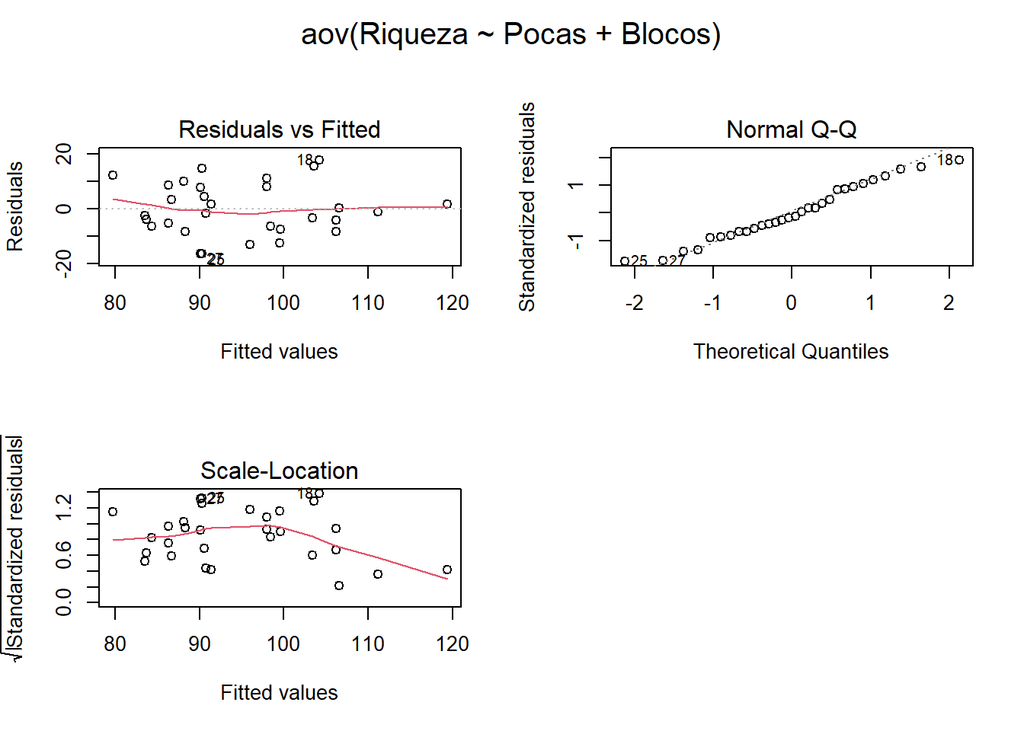

```r
# VERIFICANDO A NORMALIDADE E HOMOGENEIDADE DAS VARIÂNCIAS
#***********************************************************************
# Os gráficos *Residuals vs Fitted* e *Scale-Location* estão relacionados com a homogeneidade da variância. Nestes gráficos, esperamos ver os pontos dispersos no espaço sem padrões em forma de *U* ou funil.
# O gráfico *Normal Q-Q* está relacionado com a distribuição normal dos resíduos. Neste gráfico, esperamos ver os pontos próximos a reta sem padrões em forma de *U* ou *S*.
par(mfrow = c(2, 2), oma = c(0, 0, 2, 0))
plot(model_bloco1)
```

```r
dev.off()
```

```r
# Diferenças entre os tratamentos
#***********************************
# Teste de Tuckey's honest significant difference
library(lsmeans)
pairs(lsmeans(model_bloco1, "Pocas"), adjust = "tukey")
```

```
##  contrast            estimate   SE df t.ratio p.value
##  Borda - Int-100m      16.000 6.57 20  2.436  0.1463
##  Borda - Int-50m       19.833 6.57 20  3.020  0.0472
##  Borda - Mat-100m      15.833 6.57 20  2.411  0.1531
##  Borda - Mat-50m        8.167 6.57 20  1.244  0.7269
##  Int-100m - Int-50m     3.833 6.57 20  0.584  0.9760
##  Int-100m - Mat-100m   -0.167 6.57 20 -0.025  1.0000
##  Int-100m - Mat-50m    -7.833 6.57 20 -1.193  0.7553
##  Int-50m - Mat-100m    -4.000 6.57 20 -0.609  0.9720
##  Int-50m - Mat-50m    -11.667 6.57 20 -1.777  0.4135
##  Mat-100m - Mat-50m    -7.667 6.57 20 -1.167  0.7692
##
## Results are averaged over the levels of: Blocos
## P value adjustment: tukey method for comparing a family of 5 estimates
```

Visualizar os resultados em gráfico

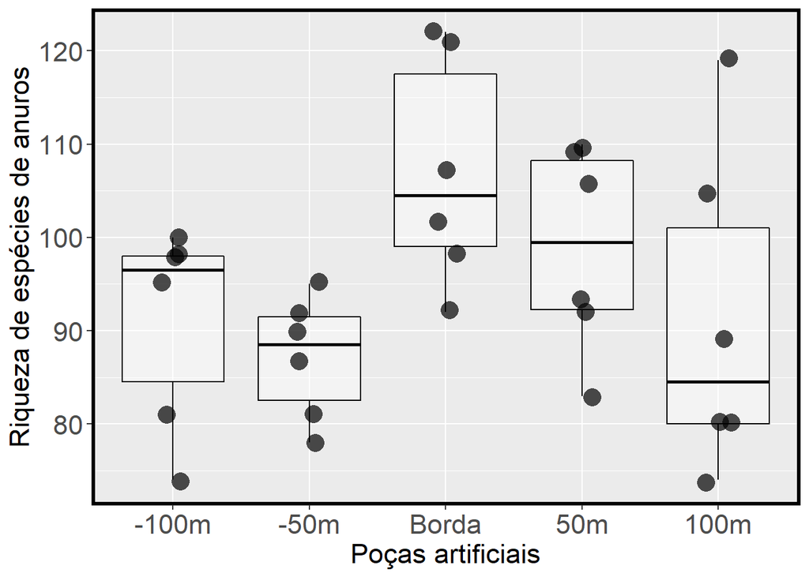

```r
# Reordenando a ordem que os grupos irão aparecer no gráfico
dados_bloco$Pocas <- factor(dados_bloco$Pocas,
                              levels=c("Int-100m", "Int-50m", "Borda", "Mat-50m", "Mat-100m"))

# Gráfico
library(ggplot2)
ggplot(data = dados_bloco, aes(x= Pocas, y= Riqueza)) +
  labs(x = "Poças artificiais", y = "Riqueza de espécies de anuros", size = 20) +
  geom_boxplot(color="black", show.legend = FALSE,
               alpha = 0.4) +
  geom_jitter(shape = 16, position=position_jitter(0.1), cex = 5, alpha = 0.7) +
  scale_x_discrete(labels=c("-100m","-50m","Borda", "50m", "100m")) +
  theme(axis.title.y = element_text(size = 17), axis.title.x = element_text(size = 17)) +
  theme(axis.text.y = element_text(size = 17), axis.text.x = element_text(size = 17)) +
  theme(panel.border = element_rect(colour = "black", fill=NA, size = 2))
```

## Análise de covariância (ANCOVA)

A ANCOVA pode ser compreendida como uma extensão da Anova com a adição de variável contínua (covariável) medida em todas as unidades amostrais (Gotelli & Ellison 2013). A ideia é que a covariável também afete os valores da variável resposta. Não incluir a covariável irá fazer com que a variação não explicada pelo modelo concentre-se nos resíduos. Incluindo a covariável, o tamanho do resíduo é menor, e o teste para avaliar as diferenças nos tratamentos terá mais poder estatístico.

#### Exemplo prático 1 - ANCOVA

##### Explicação dos dados

Neste exemplo, avaliaremos o efeito da herbivoria na biomassa dos frutos de uma espécie de árvore na Mata Atlântica. O delineamento experimental permitiu que alguns indivíduos sofressem herbivoria e outros não. Os pesquisadores também mediram o tamanho da raiz dos indíviduos para inseri-la como uma covariável no modelo.

**Pergunta:**

> A herbivoria diminiu a biomssa dos frutos?

**Predições**

> Os indivíduos que sofreram herbivoria irão produzir frutos com menor biomassa do que os indivíduos sem herbivoria.

**Variáveis**

- Variáveis preditoras
  - Dataframe com as indivíduos da espéci de planta (unidade amostral) nas linhas e o tratamento e a covariável nas colunas.

**Checklist**

- Verificar se o seu dataframe está com as unidades amostrais nas linhas e variáveis preditoras nas colunas.

### Análise

Cálculo da ANCOVA

```r
## IMPORTANDO DADOS
#********************
dados_ancova <- read.csv("ancova.csv", header = T, sep = ";")
str(dados_ancova) # verificar se o dataframe foi lido corretamente
```

```
## 'data.frame':    40 obs. of  3 variables:
##  $ Raiz      : num  6.22 6.49 4.92 5.13 5.42 ...
##  $ Biomassa  : num  59.8 61 14.7 19.3 34.2 ...
##  $ Herbivoria: chr  "Sem_herb" "Sem_herb" "Sem_herb" "Sem_herb" ...
```

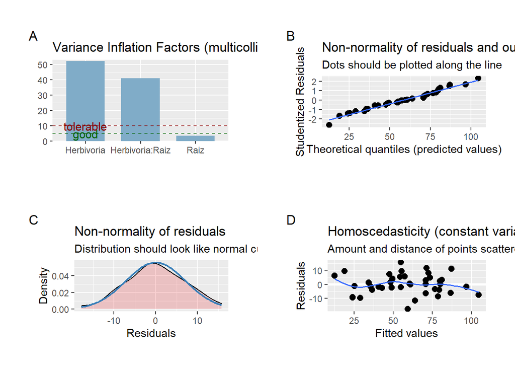

```r
# ANALISE ANCOVA
#****************************************
modelo_ancova <- lm(Biomassa ~ Herbivoria * Raiz, data = dados_ancova)

# VERIFICANDO A NORMALIDADE E HOMOGENEIDADE DAS VARIÂNCIAS
#***********************************************************************
# Esta função mostra os resultados para multicolinearidade (a), dois gráficos avaliando a normalidade dos resíduos (b e  c), e um gráfico para a homogeneidade dos resíduos (d).
library(sjPlot)
plot_grid(plot_model(modelo_ancova, type = "diag"))
```

```r
# OLHANDO OS RESULTADOS
#********************
anova(modelo_ancova)
```

```
## Analysis of Variance Table
##
## Response: Biomassa
##                 Df  Sum Sq Mean Sq F value    Pr(>F)
## Herbivoria       1  1941.9  1941.9  35.101 8.764e-07 ***
## Raiz             1 17434.1 17434.1 315.124 < 2.2e-16 ***
## Herbivoria:Raiz  1   136.7   136.7   2.471    0.1247
## Residuals       36  1991.7    55.3
## ---
## Signif. codes:  0 '***' 0.001 '**' 0.01 '*' 0.05 '.' 0.1 ' ' 1
```

Percebam que o resultado da ANCOVA (Pr(>F) < 0.001) indica que tanto a herbivoria como a o tamanho da raiz (covariável) tem efeitos significativos na biomassa dos frutos. Contudo, a interação entre as variáveis não foi signigicativa. Vamos usar o Likelihood ratio test (LRT) para ver se podemos seguir com um modelo mais simples (sem interação).

```r
modelo_ancova <- lm(Biomassa ~ Herbivoria * Raiz, data = dados_ancova)
modelo_ancova2 <- lm(Biomassa ~ Herbivoria + Raiz, data = dados_ancova)

# LRT
library(lmtest)
# A hipótese nula é que o modelo mais simples é melhor
# Valores de p < 0.05 rejeita a hipótese nula e o modelo mais complexo é o melhor
# Valores de p > 0.05 não rejeita a hipótese nula e o modelo mais simples é o melhor
lrtest(modelo_ancova, modelo_ancova2)
```

```
## Likelihood ratio test
##
## Model 1: Biomassa ~ Herbivoria * Raiz
## Model 2: Biomassa ~ Herbivoria + Raiz
##   #Df  LogLik Df  Chisq Pr(>Chisq)
## 1   5 -134.91
## 2   4 -136.24 -1 2.6554     0.1032
```

Visualizar os resultados em gráfico

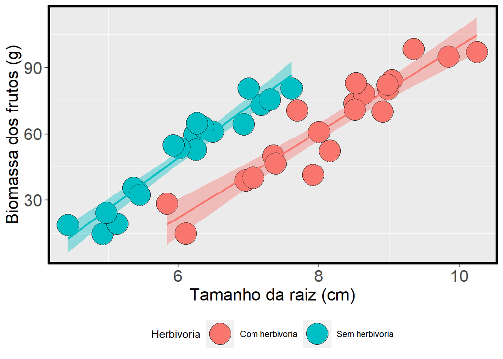

```r
# Gráfico
library(ggplot2)
ggplot(data = dados_ancova, aes(x= Raiz, y= Biomassa, fill = Herbivoria)) +
  labs(x = "Tamanho da raiz (cm)", y = "Biomassa dos frutos (g)", size = 20) +
  geom_point(size = 10, shape = 21) +
  theme(axis.title.y = element_text(size = 17), axis.title.x = element_text(size = 17)) +
  theme(axis.text.y = element_text(size = 17), axis.text.x = element_text(size = 17)) +
  theme(panel.grid.major = element_blank(),
        panel.border = element_rect(colour = "black", fill=NA, size = 2)) +
  theme(legend.position="bottom") +
  scale_fill_discrete(name = "Herbivoria", labels = c("Com herbivoria", "Sem herbivoria")) +
  geom_smooth(aes(color=Herbivoria), method="lm", show.legend = FALSE)
```

**Interpretação dos resultados**

Neste exemplo, o tamanho da raiz (covariável) tem uma relação positiva com a biomassa dos frutos. Quanto maior o tamanho da raiz, maior a biomassa dos frutos. Usando a ANCOVA e controlando o efeito da covariável, percebemos que a herbivoria também afeta a biomassa dos frutos. Os indivíduos que não sofreram herbivoria produziram frutos com maior biomassa do que os indivíduos com herbivoria.

### Para se aprofundar

- Recomendamos aos interessados os livros: i) Zar (2010) Biostatiscal analysis; ii) Gotelli & Ellison (2013) A primer of ecological statistics; e iii) Quinn & Keough (2002) Experimental design and data analysis for biologists.